# Machine Learning Predictive Model from Monitored Exercise

Marcos Medeiros

1/28/2022

## Synopsis

Using devices such as Jawbone Up, Nike FuelBand, and Fitbit it is now possible to collect a large amount of data about personal activity relatively inexpensively. One thing that people regularly do is quantify how much of a particular activity they do, but they rarely quantify how well they do it. In this project, I will use data from accelerometers on the belt, forearm, arm, and dumbell of 6 participants were asked to perform barbell lifts correctly and incorrectly in 5 different ways to predict the manner in which participants will perform a barbell lift. More information is available from the website here: http://web.archive.org/web/20161224072740/http:/groupware.les.inf.puc-rio.br/har

## Possible Outcomes

The outcome variable is `classe`, a factor variable with 5 levels of precision in a set of 10 repetitions of Unilateral Dumbbell Curl:

`class A` exactly according to the specification;

`class B` throwing the elbows to the front;

`class C` lifting the dumbbell only halfway;

`class D` lowering the dumbbell only halfway;

`class E` throwing the hips to the front.

## Data Loading and preparing analisys

```r
library(lattice)
library(ggplot2)
library(caret)
library(corrplot)
library(gbm)
library(rpart)
library(rpart.plot)
library(rattle)
trainURL <- "http://d396qusza40orc.cloudfront.net/predmachlearn/pml-training.csv"
testURL <- "http://d396qusza40orc.cloudfront.net/predmachlearn/pml-testing.csv"

training <- read.csv(url(trainURL))
testing <- read.csv(url(testURL))


## Creating a partition

label <- createDataPartition(training$classe, p = 0.7, list = FALSE)
train <- training[label, ]
test <- training[-label, ]


## Filtering data
### Excluding variables with nearly zero variance

NZV <- nearZeroVar(train)
train <- train[ ,-NZV]
test <- test[ ,-NZV]

### Excluding variables with more than 90% NAs

label <- apply(train, 2, function(x) mean(is.na(x))) > 0.90
train <- train[, -which(label, label == FALSE)]
test <- test[, -which(label, label == FALSE)]

### Excluding identification variables

train <- train[ , -(1:5)]
test <- test[ , -(1:5)]

dim(train)
```

```
## [1] 13737    54
```

```r
dim(test)
```

```
## [1] 5885   54
```

We reduced the dataset from 160 to 54 variables.

## Exploratory Analysis

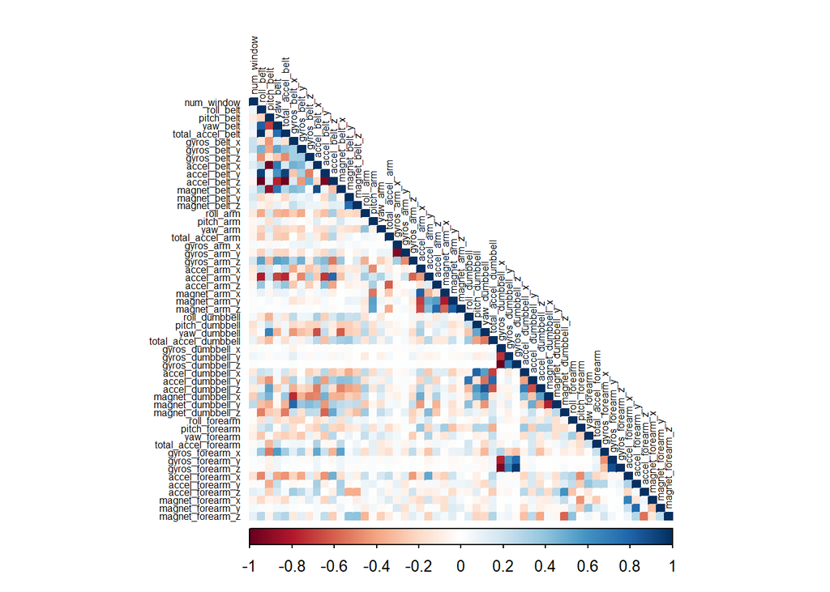

```r
## Making a correlation plot to look the dependence intensity

depend <- cor(train[,-54])
corrplot(depend, method = "color", type = "lower", tl.cex = 0.5, tl.col = rgb(0,0,0))
```

## Predictive Model Selection

To choose what method provides the best accuracy in the predictive model, we will perform Random Forest, Generalized Boosted Model and Decision Tree. A confusion matrix at the end of each model will help to compare them.

### Random Forest

```r
set.seed(14518)
control <- trainControl(method = "cv", number = 4, verboseIter=FALSE)
modelRF <- train(classe ~ ., data = train, method = "rf", trControl = control)
modelRF$finalModel
```

```
##
## Call:
##  randomForest(x = x, y = y, mtry = min(param$mtry, ncol(x)))
##                Type of random forest: classification
##                      Number of trees: 500
## No. of variables tried at each split: 27
##
##         OOB estimate of  error rate: 0.25%
## Confusion matrix:
##      A    B    C    D    E  class.error
## A 3904    1    0    0    1 0.0005120328
## B    8 2646    3    1    0 0.0045146727
## C    0    5 2391    0    0 0.0020868114
## D    0    0   11 2240    1 0.0053285968
## E    0    1    0    2 2522 0.0011881188
```

```r
predictRF <- predict(modelRF, test)
confMatRF <- confusionMatrix(predictRF, as.factor(test$classe))
confMatRF
```

```
## Confusion Matrix and Statistics
##
##           Reference
## Prediction    A    B    C    D    E
##          A 1673    2    0    0    0
##          B    1 1135    3    0    0
##          C    0    2 1023    2    0
##          D    0    0    0  962    6
##          E    0    0    0    0 1076
##
## Overall Statistics
##
##                Accuracy : 0.9973
##                  95% CI : (0.9956, 0.9984)
##     No Information Rate : 0.2845
##     P-Value [Acc > NIR] : < 2.2e-16
##
##                   Kappa : 0.9966
##
##  Mcnemar's Test P-Value : NA
##
## Statistics by Class:
##
##                      Class: A Class: B Class: C Class: D Class: E
## Sensitivity            0.9994   0.9965   0.9971   0.9979   0.9945
## Specificity            0.9995   0.9992   0.9992   0.9988   1.0000
## Pos Pred Value         0.9988   0.9965   0.9961   0.9938   1.0000
## Neg Pred Value         0.9998   0.9992   0.9994   0.9996   0.9988
## Prevalence             0.2845   0.1935   0.1743   0.1638   0.1839
## Detection Rate         0.2843   0.1929   0.1738   0.1635   0.1828
## Detection Prevalence   0.2846   0.1935   0.1745   0.1645   0.1828
## Balanced Accuracy      0.9995   0.9978   0.9981   0.9984   0.9972
```

### Generalized Boosted Model

```r
set.seed(14518)
control <- trainControl(method = "repeatedcv", number = 5, repeats = 1, verboseIter = FALSE)
modelGBM <- train(classe ~ ., data = train, trControl = control, method = "gbm", verbose = FALSE)
modelGBM$finalModel
```

```
## A gradient boosted model with multinomial loss function.
## 150 iterations were performed.
## There were 53 predictors of which 53 had non-zero influence.
```

```r
predictGBM <- predict(modelGBM, test)
confMatGBM <- confusionMatrix(predictGBM, as.factor(test$classe))
confMatGBM
```

```
## Confusion Matrix and Statistics
##
##           Reference
## Prediction    A    B    C    D    E
##          A 1672   18    0    1    2
##          B    1 1112   12    6    4
##          C    0    9 1009   20    0
##          D    1    0    5  933    9
##          E    0    0    0    4 1067
##
## Overall Statistics
##
##                Accuracy : 0.9844
##                  95% CI : (0.9809, 0.9874)
##     No Information Rate : 0.2845
##     P-Value [Acc > NIR] : < 2.2e-16
##
##                   Kappa : 0.9802
##
##  Mcnemar's Test P-Value : NA
##
## Statistics by Class:
##
##                      Class: A Class: B Class: C Class: D Class: E
## Sensitivity            0.9988   0.9763   0.9834   0.9678   0.9861
## Specificity            0.9950   0.9952   0.9940   0.9970   0.9992
## Pos Pred Value         0.9876   0.9797   0.9721   0.9842   0.9963
## Neg Pred Value         0.9995   0.9943   0.9965   0.9937   0.9969
## Prevalence             0.2845   0.1935   0.1743   0.1638   0.1839
## Detection Rate         0.2841   0.1890   0.1715   0.1585   0.1813
## Detection Prevalence   0.2877   0.1929   0.1764   0.1611   0.1820
## Balanced Accuracy      0.9969   0.9857   0.9887   0.9824   0.9927
```

### Decision Tree

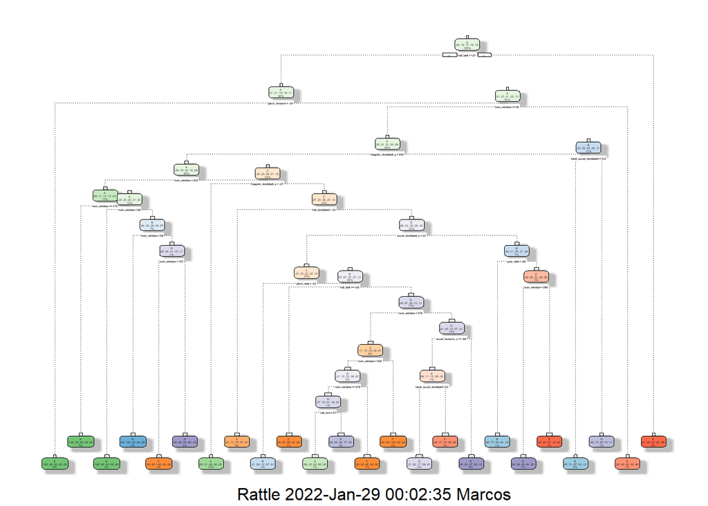

```r
set.seed(14518)
modelDT <- rpart(classe ~ ., data = train, method = "class")
fancyRpartPlot(modelDT)
```

```r
predictDT <- predict(modelDT, test, type = "class")
confMatDT <- confusionMatrix(predictDT, as.factor(test$classe))
confMatDT
```

```
## Confusion Matrix and Statistics
##
##           Reference
## Prediction    A    B    C    D    E
##          A 1515  200   46   51   10
##          B   96  775   56   42   92
##          C   22   83  875   44    3
##          D   38   48   38  767   92
##          E    3   33   11   60  885
##
## Overall Statistics
##
##                Accuracy : 0.8185
##                  95% CI : (0.8084, 0.8283)
##     No Information Rate : 0.2845
##     P-Value [Acc > NIR] : < 2.2e-16
##
##                   Kappa : 0.7698
##
##  Mcnemar's Test P-Value : 3.562e-16
##
## Statistics by Class:
##
##                      Class: A Class: B Class: C Class: D Class: E
## Sensitivity            0.9050   0.6804   0.8528   0.7956   0.8179
## Specificity            0.9271   0.9397   0.9687   0.9561   0.9777
## Pos Pred Value         0.8315   0.7304   0.8520   0.7803   0.8921
## Neg Pred Value         0.9609   0.9245   0.9689   0.9598   0.9597
## Prevalence             0.2845   0.1935   0.1743   0.1638   0.1839
## Detection Rate         0.2574   0.1317   0.1487   0.1303   0.1504
## Detection Prevalence   0.3096   0.1803   0.1745   0.1670   0.1686
## Balanced Accuracy      0.9161   0.8101   0.9108   0.8759   0.8978
```

## Predicting Results

```r
predictRF <- predict(modelRF, testing)
predictRF
```

```
##  [1] B A B A A E D B A A B C B A E E A B B B
## Levels: A B C D E
```